# main_file

STEP01: IMPORTING REQUIRED LIBRARIES FOR EDA

1. NumPy :- for numerical operations and mathematical calculations
2. Pandas :- for data loading, manipulation, and analysis
3. Matplotlib :- for basic data visualization (charts and graphs)

```python
import numpy as np
import pandas as pd
import matplotlib.pyplot as plt
import seaborn as sns
```

STEP02: DATA LOADING

- Reading the CSV file and storing it in a DataFrame called 'dataset'.

```python
dataset = pd.read_csv("data_science_salaries.csv")
dataset
```

|  | job_title | experience_level | employment_type | work_models | work_year | employee_residence | salary | salary_currency | salary_in_usd | company_location | company_size |
| --- | --- | --- | --- | --- | --- | --- | --- | --- | --- | --- | --- |
| 0 | Data Engineer | Mid-level | Full-time | Remote | 2024 | United States | 148100 | USD | 148100 | United States | Medium |
| 1 | Data Engineer | Mid-level | Full-time | Remote | 2024 | United States | 98700 | USD | 98700 | United States | Medium |
| 2 | Data Scientist | Senior-level | Full-time | Remote | 2024 | United States | 140032 | USD | 140032 | United States | Medium |
| 3 | Data Scientist | Senior-level | Full-time | Remote | 2024 | United States | 100022 | USD | 100022 | United States | Medium |
| 4 | BI Developer | Mid-level | Full-time | On-site | 2024 | United States | 120000 | USD | 120000 | United States | Medium |
| ... | ... | ... | ... | ... | ... | ... | ... | ... | ... | ... | ... |
| 6594 | Staff Data Analyst | Entry-level | Contract | Hybrid | 2020 | Canada | 60000 | CAD | 44753 | Canada | Large |
| 6595 | Staff Data Analyst | Executive-level | Full-time | On-site | 2020 | Nigeria | 15000 | USD | 15000 | Canada | Medium |
| 6596 | Machine Learning Manager | Senior-level | Full-time | Hybrid | 2020 | Canada | 157000 | CAD | 117104 | Canada | Large |
| 6597 | Data Engineer | Mid-level | Full-time | Hybrid | 2020 | Austria | 65000 | EUR | 74130 | Austria | Large |
| 6598 | Data Scientist | Senior-level | Full-time | On-site | 2020 | Austria | 80000 | EUR | 91237 | Austria | Small |

6599 rows × 11 columns

STEP03: DATASET INSPECTION

- In this step, I explore the dataset to understand its structure,
- data types, missing values, and basic patterns before analysis

```python
# 01 Check shape of dataset (rows, columns)
# This tells how big the dataset is
data_shape = dataset.shape
print(f"1. Dataset Shape (rows, columns): {data_shape}\n")


# 02 View column names
# Helps understand what features are available
data_columns = dataset.columns
print(f"2. Dataset Columns:")
for col in data_columns:
    print(col)
```

```
1. Dataset Shape (rows, columns): (6599, 11)

2. Dataset Columns:
job_title
experience_level
employment_type
work_models
work_year
employee_residence
salary
salary_currency
salary_in_usd
company_location
company_size
```

```python
# 03 View first 5 rows
# Gives a quick idea of how data looks
dataset.head()
```

|  | job_title | experience_level | employment_type | work_models | work_year | employee_residence | salary | salary_currency | salary_in_usd | company_location | company_size |
| --- | --- | --- | --- | --- | --- | --- | --- | --- | --- | --- | --- |
| 0 | Data Engineer | Mid-level | Full-time | Remote | 2024 | United States | 148100 | USD | 148100 | United States | Medium |
| 1 | Data Engineer | Mid-level | Full-time | Remote | 2024 | United States | 98700 | USD | 98700 | United States | Medium |
| 2 | Data Scientist | Senior-level | Full-time | Remote | 2024 | United States | 140032 | USD | 140032 | United States | Medium |
| 3 | Data Scientist | Senior-level | Full-time | Remote | 2024 | United States | 100022 | USD | 100022 | United States | Medium |
| 4 | BI Developer | Mid-level | Full-time | On-site | 2024 | United States | 120000 | USD | 120000 | United States | Medium |

```python
# 04 Get basic info about dataset
# Shows data types, non-null values, memory usage
dataset.info()
```

```
<class 'pandas.core.frame.DataFrame'>
RangeIndex: 6599 entries, 0 to 6598
Data columns (total 11 columns):
 #   Column              Non-Null Count  Dtype
---  ------              --------------  -----
 0   job_title           6599 non-null   object
 1   experience_level    6599 non-null   object
 2   employment_type     6599 non-null   object
 3   work_models         6599 non-null   object
 4   work_year           6599 non-null   int64
 5   employee_residence  6599 non-null   object
 6   salary              6599 non-null   int64
 7   salary_currency     6599 non-null   object
 8   salary_in_usd       6599 non-null   int64
 9   company_location    6599 non-null   object
 10  company_size        6599 non-null   object
dtypes: int64(3), object(8)
memory usage: 567.2+ KB
```

```python
# 05 Statistical summary of numeric columns
# Helps understand distribution (mean, min, max, etc.)
dataset.describe()
```

|  | work_year | salary | salary_in_usd |
| --- | --- | --- | --- |
| count | 6599.000000 | 6.599000e+03 | 6599.000000 |
| mean | 2022.818457 | 1.792833e+05 | 145560.558569 |
| std | 0.674809 | 5.263722e+05 | 70946.838070 |
| min | 2020.000000 | 1.400000e+04 | 15000.000000 |
| 25% | 2023.000000 | 9.600000e+04 | 95000.000000 |
| 50% | 2023.000000 | 1.400000e+05 | 138666.000000 |
| 75% | 2023.000000 | 1.875000e+05 | 185000.000000 |
| max | 2024.000000 | 3.040000e+07 | 750000.000000 |

```python
# 06 Check missing values in each column
# Helps identify data quality issues
missing_values = dataset.isnull().sum()
print(f"1. Missing Values of Dataset(Column-wise):\n{missing_values}\n")


# 07 Check duplicate rows
# Ensures there is no repeated data
duplicate_count = dataset.duplicated().sum()
print(f"2. Duplicate Rows Count: {duplicate_count}")
```

```
1. Missing Values of Dataset(Column-wise):
job_title             0
experience_level      0
employment_type       0
work_models           0
work_year             0
employee_residence    0
salary                0
salary_currency       0
salary_in_usd         0
company_location      0
company_size          0
dtype: int64

2. Duplicate Rows Count: 0
```

```python
# 08 Unique values in important columns
# Helps understand category diversity

print(f"job_title: {dataset["job_title"].nunique()}")
print(f"experience_level: {dataset["experience_level"].nunique()}")
print(f"employment_type: {dataset["employment_type"].nunique()}")
print(f"work_models: {dataset["work_models"].nunique()}")
print(f"work_year: {dataset["work_year"].nunique()}")
print(f"company_size: {dataset["company_size"].nunique()}")
```

```
job_title: 132
experience_level: 4
employment_type: 4
work_models: 3
work_year: 5
company_size: 3
```

```python
# 09 Frequency of categorical columns
# Shows most common categories in each column with their counts sorted in descending order

print(f"{dataset["job_title"].value_counts()}\n")
print(f"{dataset["experience_level"].value_counts()}\n")
print(f"{dataset["employment_type"].value_counts()}\n")
print(f"{dataset["work_models"].value_counts()}\n")
print(f"{dataset["work_year"].value_counts()}\n")
print(f"{dataset["company_size"].value_counts()}\n")
```

```
job_title
Data Engineer                1307
Data Scientist               1243
Data Analyst                  910
Machine Learning Engineer     629
Analytics Engineer            246
                             ...
Deep Learning Researcher        1
Power BI Developer              1
Marketing Data Scientist        1
AI Product Manager              1
Sales Data Analyst              1
Name: count, Length: 132, dtype: int64

experience_level
Senior-level       4105
Mid-level          1675
Entry-level         565
Executive-level     254
Name: count, dtype: int64

employment_type
Full-time    6552
Contract       19
Part-time      16
Freelance      12
Name: count, dtype: int64

work_models
On-site    3813
Remote     2561
Hybrid      225
Name: count, dtype: int64

work_year
2023    4625
2022    1112
2024     571
2021     216
2020      75
Name: count, dtype: int64

company_size
Medium    5860
Large      569
Small      170
Name: count, dtype: int64
```

STEP04: DATA CLEANING & MANIPULATION

- In this step, I prepare the dataset for analysis by cleaning and transforming it.
- I check for missing values, duplicate records, and any inconsistencies in the data.
- These steps help improve the overall quality and usability of the dataset

```python
# A. Created a copy of the original dataset to preserve raw data
# All cleaning and transformations will be done on this copy

dataset_copy = dataset.copy()
dataset_copy
```

|  | job_title | experience_level | employment_type | work_models | work_year | employee_residence | salary | salary_currency | salary_in_usd | company_location | company_size |
| --- | --- | --- | --- | --- | --- | --- | --- | --- | --- | --- | --- |
| 0 | Data Engineer | Mid-level | Full-time | Remote | 2024 | United States | 148100 | USD | 148100 | United States | Medium |
| 1 | Data Engineer | Mid-level | Full-time | Remote | 2024 | United States | 98700 | USD | 98700 | United States | Medium |
| 2 | Data Scientist | Senior-level | Full-time | Remote | 2024 | United States | 140032 | USD | 140032 | United States | Medium |
| 3 | Data Scientist | Senior-level | Full-time | Remote | 2024 | United States | 100022 | USD | 100022 | United States | Medium |
| 4 | BI Developer | Mid-level | Full-time | On-site | 2024 | United States | 120000 | USD | 120000 | United States | Medium |
| ... | ... | ... | ... | ... | ... | ... | ... | ... | ... | ... | ... |
| 6594 | Staff Data Analyst | Entry-level | Contract | Hybrid | 2020 | Canada | 60000 | CAD | 44753 | Canada | Large |
| 6595 | Staff Data Analyst | Executive-level | Full-time | On-site | 2020 | Nigeria | 15000 | USD | 15000 | Canada | Medium |
| 6596 | Machine Learning Manager | Senior-level | Full-time | Hybrid | 2020 | Canada | 157000 | CAD | 117104 | Canada | Large |
| 6597 | Data Engineer | Mid-level | Full-time | Hybrid | 2020 | Austria | 65000 | EUR | 74130 | Austria | Large |
| 6598 | Data Scientist | Senior-level | Full-time | On-site | 2020 | Austria | 80000 | EUR | 91237 | Austria | Small |

6599 rows × 11 columns

```python
# B. Replaced abbreviations and inconsistent job titles with standardized full forms
# This ensures uniformity in job_title column for better analysis

dataset_copy["job_title"] = dataset_copy["job_title"].replace({
    "ML Engineer": "Machine Learning Engineer",
    "BI Developer": "Business Intelligence Developer",
    "BI Analyst": "Business Intelligence Analyst",
    "BI Data Analyst": "Business Intelligence Data Analyst",
    "Data Science": "Data Scientist",
    "Data Modeller": "Data Modeler",
    "ETL Developer": "ETL Engineer"
})
```

```python
# C. Created and Inserted "job_category" column
# This feature engineering step was performed to group similar job titles into meaningful categories
# It was necessary because the dataset contained a large number of unique job titles across similar roles,
# which made the data messy and difficult to analyze effectively during EDA and further analysis.



# step1: Defined func to assign category to each job_title respectively
def get_category(title):

    t = title.lower()


    # a. EXACT MATCH:
    exact_map = {
        "data engineer": "Data Engineering",
        "etl engineer": "Data Engineering",
        "big data engineer": "Data Engineering",
        "cloud data engineer": "Data Engineering",
        "azure data engineer": "Data Engineering",
        "software data engineer": "Data Engineering",
        "data developer": "Data Engineering",
        "data scientist": "Data Science",
        "data analyst": "Data Analysis",
        "machine learning engineer": "Machine Learning & AI",
        "ai engineer": "Machine Learning & AI",
        "business intelligence analyst": "Business Intelligence",
        "data architect": "Data Architecture",
        "big data architect": "Data Architecture",
        "data science manager": "Leadership & Management",
        "head of data science": "Leadership & Management",
        "director of data science": "Leadership & Management",
    }

    if t in exact_map:
        return exact_map[t]


    # b. KEYWORD MATCH:

    # Leadership
    if any(k in t for k in ["lead", "head", "director", "manager", "principal", "staff"]):
        return "Leadership & Management"

    # Data Engineering
    if any(k in t for k in ["etl", "data engineer", "infrastructure", "integration", "pipeline", "devops"]):
        return "Data Engineering"

    # Data Science
    if any(k in t for k in ["scientist", "research scientist", "applied scientist"]):
        return "Data Science"

    # Machine Learning / AI
    if any(k in t for k in ["machine learning", "ml", "ai", "deep learning", "nlp", "computer vision"]):
        return "Machine Learning & AI"

    # Data Analysis
    if any(k in t for k in ["analyst", "analytics", "visualization", "insight"]):
        return "Data Analysis"

    # Business Intelligence
    if any(k in t for k in ["business intelligence", "bi", "power bi"]):
        return "Business Intelligence"

    # Data Architecture
    if any(k in t for k in ["architect", "modeler", "data architect"]):
        return "Data Architecture"


    # c. IF NONE, RETURN "Other"
    return "Other"





# step2: Applied categorization function to job_title column
new_col_values = dataset_copy["job_title"].apply(get_category)





# step3: Inserted job_category column at position 1 (right after job_title)
dataset_copy.insert(loc=1, column="job_category", value=new_col_values)
dataset_copy
```

|  | job_title | job_category | experience_level | employment_type | work_models | work_year | employee_residence | salary | salary_currency | salary_in_usd | company_location | company_size |
| --- | --- | --- | --- | --- | --- | --- | --- | --- | --- | --- | --- | --- |
| 0 | Data Engineer | Data Engineering | Mid-level | Full-time | Remote | 2024 | United States | 148100 | USD | 148100 | United States | Medium |
| 1 | Data Engineer | Data Engineering | Mid-level | Full-time | Remote | 2024 | United States | 98700 | USD | 98700 | United States | Medium |
| 2 | Data Scientist | Data Science | Senior-level | Full-time | Remote | 2024 | United States | 140032 | USD | 140032 | United States | Medium |
| 3 | Data Scientist | Data Science | Senior-level | Full-time | Remote | 2024 | United States | 100022 | USD | 100022 | United States | Medium |
| 4 | Business Intelligence Developer | Business Intelligence | Mid-level | Full-time | On-site | 2024 | United States | 120000 | USD | 120000 | United States | Medium |
| ... | ... | ... | ... | ... | ... | ... | ... | ... | ... | ... | ... | ... |
| 6594 | Staff Data Analyst | Leadership & Management | Entry-level | Contract | Hybrid | 2020 | Canada | 60000 | CAD | 44753 | Canada | Large |
| 6595 | Staff Data Analyst | Leadership & Management | Executive-level | Full-time | On-site | 2020 | Nigeria | 15000 | USD | 15000 | Canada | Medium |
| 6596 | Machine Learning Manager | Leadership & Management | Senior-level | Full-time | Hybrid | 2020 | Canada | 157000 | CAD | 117104 | Canada | Large |
| 6597 | Data Engineer | Data Engineering | Mid-level | Full-time | Hybrid | 2020 | Austria | 65000 | EUR | 74130 | Austria | Large |
| 6598 | Data Scientist | Data Science | Senior-level | Full-time | On-site | 2020 | Austria | 80000 | EUR | 91237 | Austria | Small |

6599 rows × 12 columns

```python
# D. Detecting and handling outliers in "salary_in_usd" for better analysis

# step1: check summary statistics to understand overall salary range and spot extreme values
dataset_copy["salary_in_usd"].describe()
```

```
count      6599.000000
mean     145560.558569
std       70946.838070
min       15000.000000
25%       95000.000000
50%      138666.000000
75%      185000.000000
max      750000.000000
Name: salary_in_usd, dtype: float64
```

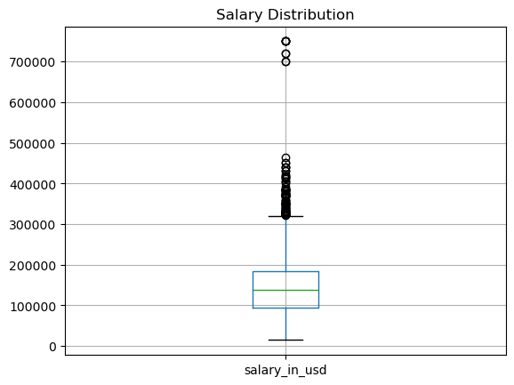

```python
# step2: visualize distribution using a boxplot to understand spread and identify outliers
dataset_copy.boxplot(column="salary_in_usd")
plt.title("Salary Distribution")
plt.show()

# Observation:
# The salary distribution is right-skewed
# Most salaries are in the lower to mid range,
# while a few very high salaries are stretching the upper side.

# Important Note:
# Since the dataset contains different job levels,
# high salaries (especially for senior roles) may be valid and not true outliers.

# So instead of removing outliers from the whole dataset,
# I'll detect outliers within each job level separately.
# This ensures I don't remove valid high salaries by mistake
```

```python
# step3: Detect outliers using group-wise IQR (based on experience level)

def find_outliers_groupwise(df, group_col, target_col):
    outlier_df = pd.DataFrame()

    for group in df[group_col].unique():
        subset = df[df[group_col] == group]

        # Calculate IQR
        Q1 = subset[target_col].quantile(0.25)
        Q3 = subset[target_col].quantile(0.75)
        IQR = Q3 - Q1

        # Define bounds
        lower_bound = Q1 - 1.5 * IQR
        upper_bound = Q3 + 1.5 * IQR
        print(f"{group}: {lower_bound}, {upper_bound}")

        # Identify outliers
        outliers = subset[
            (subset[target_col] < lower_bound) |
            (subset[target_col] > upper_bound)
        ]

        outlier_df = pd.concat([outlier_df, outliers])

    return outlier_df

print("1. Experience Level Lower & Upper Bounds:")
outliers_df = find_outliers_groupwise(dataset_copy, group_col="experience_level", target_col="salary_in_usd")
print(f"\n2. Total Outliers: {len(outliers_df)}\n")

# Observation:
# - Detected 133 outliers using group-wise IQR
# - Since salary is right-skewed, not all outliers are incorrect
# - High salaries (especially senior/executive) can be valid


# step4: Review extreme outliers
print(f"3. Top 20 Outliers:")
outliers_df.sort_values(by="salary_in_usd", ascending=False).head(20)

# Insight:
# - Found some mid-level salaries (~700k–750k) higher than executive level (~465k)
# - This breaks expected job hierarchy → likely data errors
# - These extreme values will be removed
```

```
1. Experience Level Lower & Upper Bounds:
Mid-level: -41192.5, 264715.5
Senior-level: -3800.0, 321000.0
Entry-level: -40885.0, 200531.0
Executive-level: -5000.0, 371000.0

2. Total Outliers: 133

3. Top 20 Outliers:
```

|  | job_title | job_category | experience_level | employment_type | work_models | work_year | employee_residence | salary | salary_currency | salary_in_usd | company_location | company_size |
| --- | --- | --- | --- | --- | --- | --- | --- | --- | --- | --- | --- | --- |
| 848 | Machine Learning Scientist | Data Science | Mid-level | Full-time | On-site | 2023 | United States | 750000 | USD | 750000 | United States | Medium |
| 852 | Machine Learning Engineer | Machine Learning & AI | Mid-level | Full-time | On-site | 2023 | United States | 750000 | USD | 750000 | United States | Medium |
| 1540 | Data Engineer | Data Engineering | Mid-level | Full-time | On-site | 2023 | United States | 750000 | USD | 750000 | United States | Medium |
| 1611 | Data Scientist | Data Science | Senior-level | Full-time | On-site | 2023 | United States | 750000 | USD | 750000 | United States | Medium |
| 296 | Machine Learning Scientist | Data Science | Mid-level | Full-time | On-site | 2024 | United States | 750000 | USD | 750000 | United States | Medium |
| 321 | Research Engineer | Other | Mid-level | Full-time | On-site | 2024 | United States | 720000 | USD | 720000 | United States | Medium |
| 329 | Research Scientist | Data Science | Mid-level | Full-time | On-site | 2024 | United States | 720000 | USD | 720000 | United States | Medium |
| 1509 | Analytics Engineer | Data Analysis | Mid-level | Full-time | Remote | 2023 | United States | 700000 | USD | 700000 | United States | Medium |
| 1095 | Analytics Engineer | Data Analysis | Senior-level | Full-time | Remote | 2023 | United States | 700000 | USD | 700000 | United States | Medium |
| 1354 | Data Engineer | Data Engineering | Executive-level | Full-time | On-site | 2023 | United States | 465000 | USD | 465000 | United States | Medium |
| 6529 | Research Scientist | Data Science | Mid-level | Full-time | On-site | 2020 | United States | 450000 | USD | 450000 | United States | Medium |
| 150 | Research Engineer | Other | Senior-level | Full-time | On-site | 2024 | United States | 450000 | USD | 450000 | United States | Medium |
| 84 | Research Engineer | Other | Senior-level | Full-time | On-site | 2024 | United States | 440000 | USD | 440000 | United States | Medium |
| 129 | Research Engineer | Other | Mid-level | Full-time | On-site | 2024 | United States | 440000 | USD | 440000 | United States | Medium |
| 170 | Research Scientist | Data Science | Senior-level | Full-time | On-site | 2024 | United States | 440000 | USD | 440000 | United States | Medium |
| 6120 | Data Analyst | Data Analysis | Mid-level | Full-time | On-site | 2022 | United Kingdom | 350000 | GBP | 430967 | United Kingdom | Medium |
| 4830 | Analytics Engineer | Data Analysis | Mid-level | Full-time | On-site | 2023 | United Kingdom | 350000 | GBP | 430640 | United Kingdom | Medium |
| 6403 | Applied Machine Learning Scientist | Data Science | Mid-level | Full-time | Hybrid | 2021 | United States | 423000 | USD | 423000 | United States | Large |
| 82 | Machine Learning Engineer | Machine Learning & AI | Senior-level | Full-time | Remote | 2024 | United States | 418000 | USD | 418000 | United States | Medium |
| 4571 | AI Scientist | Data Science | Senior-level | Full-time | On-site | 2023 | Israel | 1500000 | ILS | 417937 | Israel | Large |

```python
# step5: Filter out unrealistic extreme salaries and create clean dataset
clean_dataset = dataset_copy[dataset_copy["salary_in_usd"] < 600000]

# Final:
# - Removed only extreme unrealistic values (≥700k approx)
# - Kept valid high salaries (400k–465k range)
# - Dataset is now more realistic and balanced

# Dataset is ready for EDA / further analysis
clean_dataset
```

|  | job_title | job_category | experience_level | employment_type | work_models | work_year | employee_residence | salary | salary_currency | salary_in_usd | company_location | company_size |
| --- | --- | --- | --- | --- | --- | --- | --- | --- | --- | --- | --- | --- |
| 0 | Data Engineer | Data Engineering | Mid-level | Full-time | Remote | 2024 | United States | 148100 | USD | 148100 | United States | Medium |
| 1 | Data Engineer | Data Engineering | Mid-level | Full-time | Remote | 2024 | United States | 98700 | USD | 98700 | United States | Medium |
| 2 | Data Scientist | Data Science | Senior-level | Full-time | Remote | 2024 | United States | 140032 | USD | 140032 | United States | Medium |
| 3 | Data Scientist | Data Science | Senior-level | Full-time | Remote | 2024 | United States | 100022 | USD | 100022 | United States | Medium |
| 4 | Business Intelligence Developer | Business Intelligence | Mid-level | Full-time | On-site | 2024 | United States | 120000 | USD | 120000 | United States | Medium |
| ... | ... | ... | ... | ... | ... | ... | ... | ... | ... | ... | ... | ... |
| 6594 | Staff Data Analyst | Leadership & Management | Entry-level | Contract | Hybrid | 2020 | Canada | 60000 | CAD | 44753 | Canada | Large |
| 6595 | Staff Data Analyst | Leadership & Management | Executive-level | Full-time | On-site | 2020 | Nigeria | 15000 | USD | 15000 | Canada | Medium |
| 6596 | Machine Learning Manager | Leadership & Management | Senior-level | Full-time | Hybrid | 2020 | Canada | 157000 | CAD | 117104 | Canada | Large |
| 6597 | Data Engineer | Data Engineering | Mid-level | Full-time | Hybrid | 2020 | Austria | 65000 | EUR | 74130 | Austria | Large |
| 6598 | Data Scientist | Data Science | Senior-level | Full-time | On-site | 2020 | Austria | 80000 | EUR | 91237 | Austria | Small |

6590 rows × 12 columns

```python
# step6: Analyze clean dataset
print(clean_dataset.describe(), "\n")

# Insights:
# - After removing extreme outliers, salary distribution is more realistic
# - Maximum salary reduced from ~750k to ~465k
# - Mean and median are closer → skewness reduced
```

```
         work_year        salary  salary_in_usd
count  6590.000000  6.590000e+03    6590.000000
mean   2022.817754  1.785281e+05  144759.351442
std       0.674776  5.263339e+05   67594.214921
min    2020.000000  1.400000e+04   15000.000000
25%    2023.000000  9.600000e+04   95000.000000
50%    2023.000000  1.400000e+05  138325.000000
75%    2023.000000  1.870750e+05  185000.000000
max    2024.000000  3.040000e+07  465000.000000
```

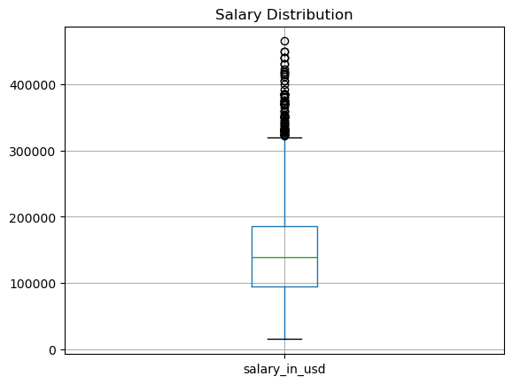

```python
clean_dataset.boxplot(column="salary_in_usd")
plt.title("Salary Distribution")
plt.show()

# Boxplot Insights:
# - Distribution remains right-skewed
# - Most salaries lie in a lower to mid range, with few high values
# - Remaining outliers represent valid high-paying roles, not errors
# - Dataset is now clean and ready for further analysis
```

STEP05: EXPLORATORY DATA ANALYSIS (EDA)

- In this step, I analyze the cleaned dataset to extract meaningful insights
- The goal is to understand patterns, trends, relationships, and visualize the data effectively.

KEY FOCUS AREAS:

- Identify most in-demand job roles
- Analyze salary distribution across different roles
- Compare salaries based on experience levels
- Understand work models (Remote / Hybrid / On-site)
- Study company size and hiring patterns
- Analyze relationship between year and salary (trend and correlation)

EDA SECTION 01: Analyzed Job Listings Across Different Data Domains

- This section analyzes the number of job listings across different data domains
- The goal is to understand which domains have the highest demand
- This helps us understand where most job opportunities are concentrated in the data field

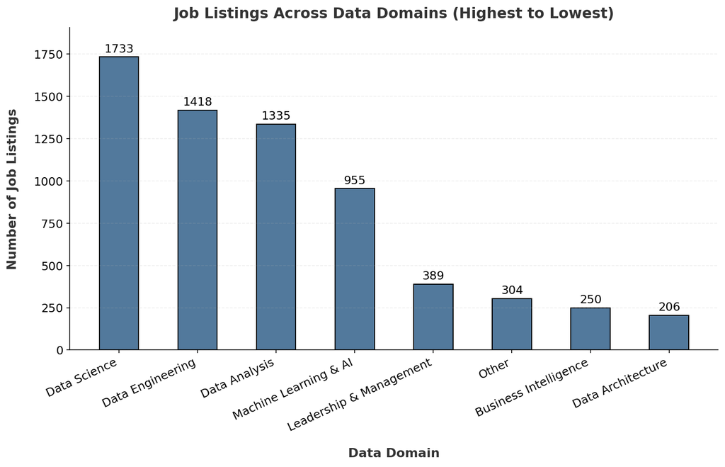

```python
# Data
most_demand_job = clean_dataset["job_category"].value_counts()
x = most_demand_job.index
y = most_demand_job.values

# Global style
plt.rcParams['font.family'] = 'sans-serif'

# Figure
plt.figure(figsize=(12, 6), dpi=150)

# Plot
plt.bar(x, y, width=0.5, edgecolor="black", color="#52799C")

# Titles & Labels
plt.title("Job Listings Across Data Domains (Highest to Lowest)",
            fontdict={"color":"#333333", "fontweight":"bold", "fontsize":15},
            pad=10)

plt.xlabel("Data Domain",
            fontdict={"color":"#333333", "fontweight":"bold", "fontsize":13},
            labelpad=15)

plt.ylabel("Number of Job Listings",
            fontdict={"color":"#333333", "fontweight":"bold", "fontsize":13},
            labelpad=15)

# Ticks
plt.xticks(rotation=25, ha='right', fontsize=12)
plt.yticks(fontsize=12)


# Value labels
for i, v in enumerate(y):
    plt.text(i, v + max(y)*0.008, str(v), ha='center', va='bottom', fontsize=12)

# Axis limits & spacing
plt.ylim(0, max(y) * 1.1)
plt.margins(y=0.05)

# Grid
plt.grid(axis='y', linestyle='--', alpha=0.2)

# Clean spines
plt.gca().spines['top'].set_visible(False)
plt.gca().spines['right'].set_visible(False)

# Show
plt.show()
```

KEY INSIGHTS OF EDA SECTION 01:

- Data Science domain has the highest number of job listings (High Demand), followed by Data Engineering and Data Analysis.
- This shows that Data Science Domain dominate the job market in this dataset compared to other data domains.

EDA SECTION 02: Identified Top Job Roles Within Each Data Domain Based on Job Listings

- This section identifies the top job roles within each data domain based on job listings
- The goal is to understand which roles are most in demand in each domain
- This helps identify the most common career paths across different data fields

```python
# Step 1: Compute job role frequency within each domain
# This gives us how many listings exist for each (job_category, job_title) pair

job_role_count = clean_dataset.groupby(["job_category", "job_title"]).size().reset_index(name="count")
```

```python
# Step02: Function to Plot Top Job Roles for Any Domain

def plot_domain(domain):

    # Filter data for selected domain and get top 5 job roles
    temp = job_role_count[job_role_count["job_category"] == domain].sort_values("count", ascending=False).head()

    # Wrap long job titles for better readability
    import textwrap
    wrapped_labels = [textwrap.fill(label, 12) for label in temp["job_title"]]

    # Create figure
    plt.figure(figsize=(12, 6), dpi=150)

    # Bar plot
    plt.bar(wrapped_labels, temp["count"], width=0.5, edgecolor="black", color="#52799C")

    # Titles and labels
    plt.title(
        f"Top {domain} Job Roles by Job Listings",
        color="#333333",
        fontweight="bold",
        fontsize=15,
        pad=10
    )
    plt.xlabel("Job Role", fontweight="bold", fontsize=13, labelpad=10, color="#333333")
    plt.ylabel("Number of Job Listings", fontweight="bold", fontsize=13, labelpad=10, color="#333333")

    # Axis formatting
    plt.xticks(rotation=0, fontsize=12)
    plt.yticks(fontsize=12)

    # Add value labels on bars
    for i, v in enumerate(temp["count"]):
        plt.text(
            i,
            v + max(temp["count"]) * 0.008,
            str(v),
            ha='center',
            va='bottom',
            fontsize=12
        )

    # Styling improvements
    plt.ylim(0, max(temp["count"]) * 1.1)
    plt.margins(y=0.05)
    plt.grid(axis='y', linestyle='--', alpha=0.3)

    # Remove unnecessary borders
    plt.gca().spines['top'].set_visible(False)
    plt.gca().spines['right'].set_visible(False)


    plt.show()
```

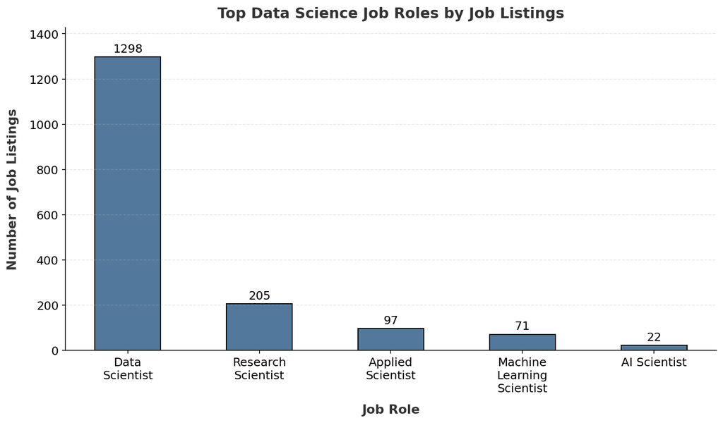

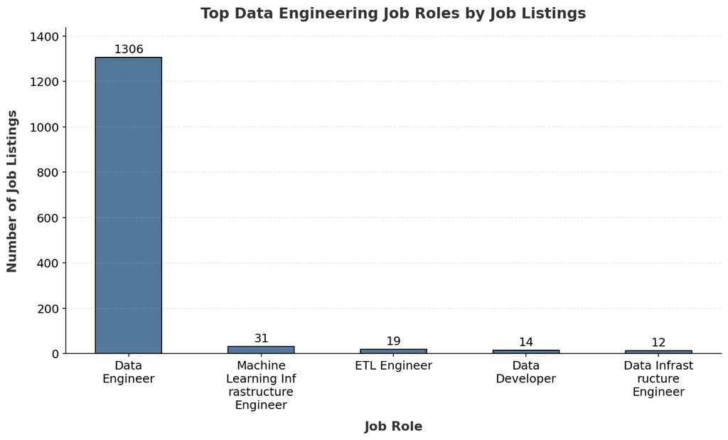

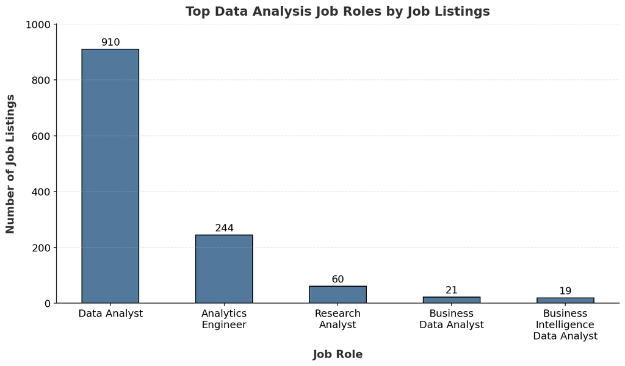

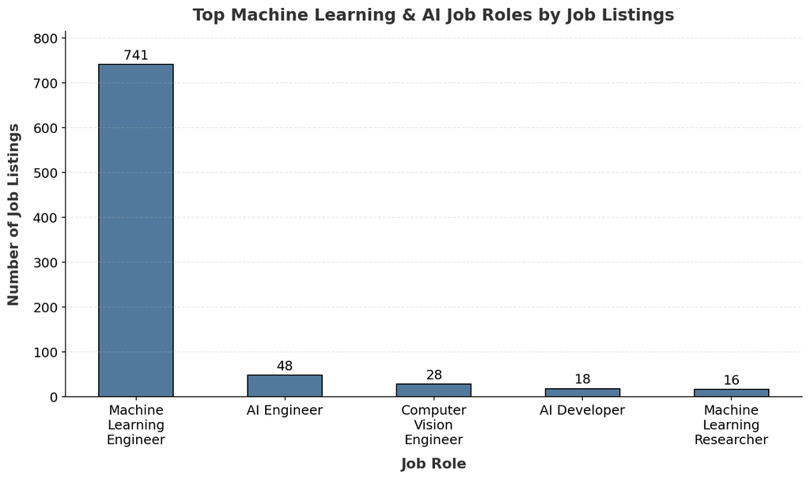

[figure not shown]

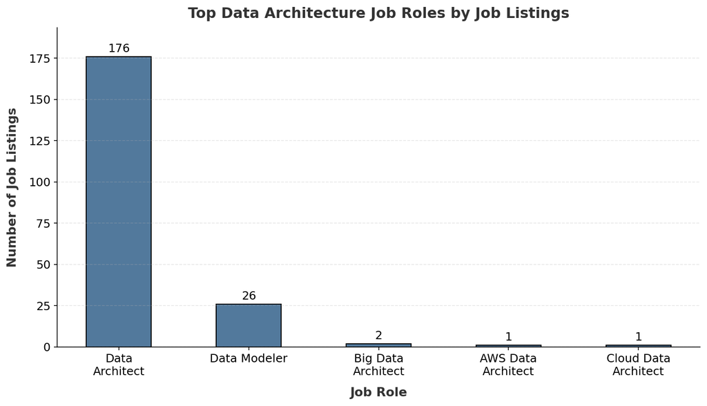

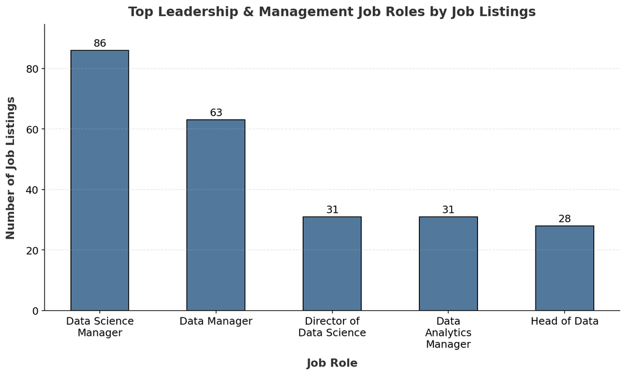

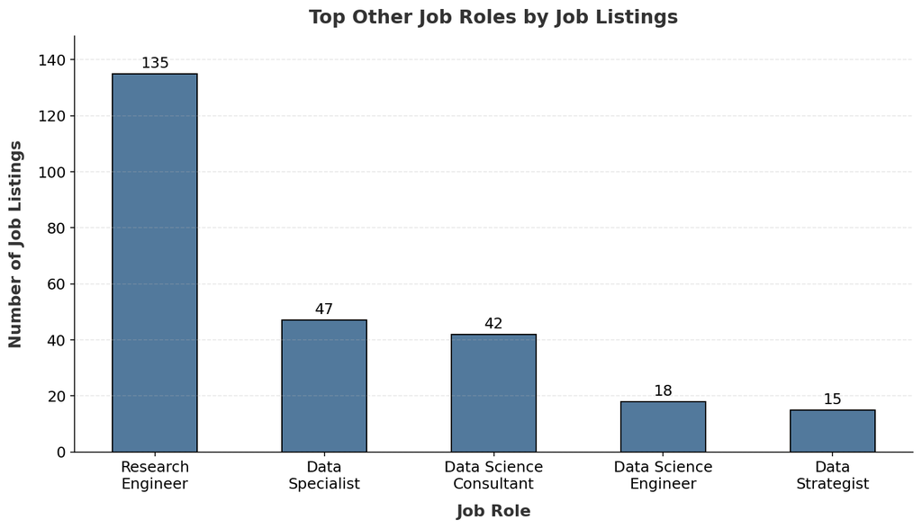

```python
plot_domain("Data Science")
plot_domain("Data Engineering")
plot_domain("Data Analysis")
plot_domain("Machine Learning & AI")
plot_domain("Business Intelligence")
plot_domain("Data Architecture")
plot_domain("Leadership & Management")
plot_domain("Other")
```

KEY INSIGHTS OF EDA SECTION 02: